# A data-driven typology of Parliamentary Representatives in Singapore

The key element in any type of democracy is representation. Consequently, representatives, especially the elected representatives, occupy the central role in day-to-day functioning of any democracy. We aim to develop a data driven typology of elected representatives based on their individual features, such as demographics, party affiliation, and more importantly their representative activity. To this end, we utilize a set of indicators from Singaporean national parliament covering the span of 2011-2020.

Ng Yi Ming (Yale-NUS College, Division of Social Sciences) , Hasti Narimanzadeh (Aalto University School of Science and Technology, Department of Computer Science) , Sina Özddemir (Norwegian University of Science and Technology, Department of Sociology and Political Science)  
2021-06-24

# Introduction

Parliamentary questions (PQs) are a common feature in Westminster-style Parliaments where representatives ask questions on any topics to ministers. Do to the relative low party control over PQ use, PQs are a uniquely valuable dataset to track the representative orientations of MPs, such as their policy interests and preferences. Existing studies of PQs around the world have combined PQ data with MP-level characteristics to study various hypotheses of what drives PQ topics, including individual demographic factors like race and gender, electoral factors like winning margin or political section, and institutional factors like parliamentary roles and party affiliation.

However, existing literature is limited to understanding isolated relations between individual factors and PQ activity outcomes. There is a lack of a holistic analysis simultaneously considering all available factors of MP-level traits and PQ activity, to understand broader typologies of MPs and their PQ representative behaviour.

# Notes and to-do:

1. Adjust the scales and legends of the visualizations for the presentation
2. Reduce dimensions
3. Do clustering
   - K-means
   - Hierarchical
   - LPA
4. Visualize the cluster centroids
   - Radar plot
   - Lollipop plot
   - Good old bar-plot/scatter-plot
5. Add Hasti’s code chunk into the document

# Data Overview

Let’s start by examining the data. Below are the descriptive statistics

[figure not shown]

## Imputations

For the win variable, if they have a party affiliation put the average winning percentage for the party in NAs. For independents either put 0 to indicate they were nominated by public or replace them with sample mean.

Ret: if the candidate is publicly nominated, ret = 1, if they are best losers, Nym will look it up.

Exp: if publicly nominated (MP = NMP) 0,

## Data transformations

### Representative performance:

The last dimension in our elected representatives typology is the representative performance. We conceive representative performance as the policy focus and intensity with which the elected representative fulfill their mandate. To approximate the policy focus, we make use of the parliamentary question sessions where the MPs pose questions to various ministries in Singapore. We argue that these questions indicates two key factors. First of which is the salient policy issues for the MPs, thus give us an insight into the policy focus of MPs during their representative mandate. The secondly, the frequency of asking questions indicates how hard the MPs work to fulfill their representative mandate. We can summarize our conceptualization of representative performance in a simple 2x2 table:

Representative Performance

|  | Low intensity of questions | High intensity of Question |
| --- | --- | --- |
| **Narrow policy focus** | TYPE A | TYPE B |
| **Diverse policy focus** | TYPE C | TYPE D |

We measure the intensity of representative performance as the number of questions asked by an MP per parliamentary season.**[Nym needs to double check these claims!]** While there are some restrictions imposed on the number of questions an MP can ask per session, how often MPs can join in the question session is up to them. Therefore, number of questions per season can serve as a suitable proxy on how much effort MPs spend to fulfill their mandate.

We approximate the diversity of policy focus of MPs via two indicators. Our first indicator is the number of times an MP has addressed different ministers. Since ministers have relatively narrower, and pre-determined, policy focus, choosing a minister as an addressee of a question roughly indicates the policy focus of the question. Thus, more diverse the addressees through out a parliamentary season, more diverse the policy focus of the MP. Our second indicator, on the other hand, zooms in on the substance of the questions. While addressee ministers gives us a impression of the diversity of policy focus of the MP, it is not a fine grained picture of the policy focus. Even though the ministers have a limited policy area, they have authority over wide variety of the issues concerning a policy area. For example, minister of defense can not only be responsible for military but also non-military related security issues such as refugees. To identify the policy area of the questions asked by MPs, we ran Dirichlet Multinominal Mixture Mode(GSDMM) (Yin and Wang, 2014) topic modeling on the question texts. Compared to more established topic modeling strategies such as LDA and STM, DMM has been shown to infer the number of clusters automatically with a good balance between the completeness and homogeneity of the clustering results using short text. Since the average length of parliamentary questions is 35 words, GSDMM proved to be a more suitable method.

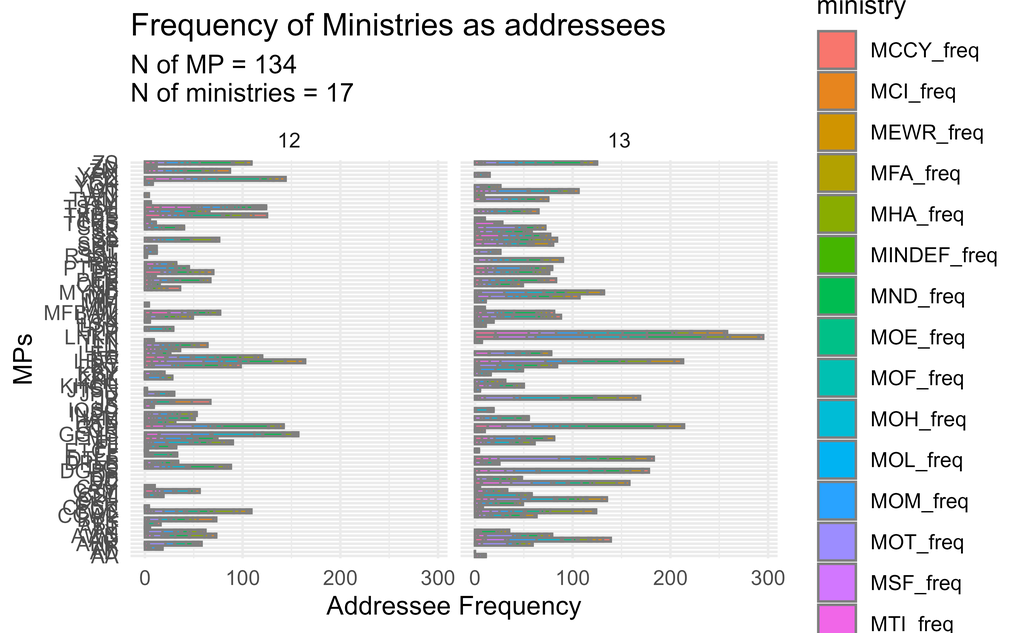

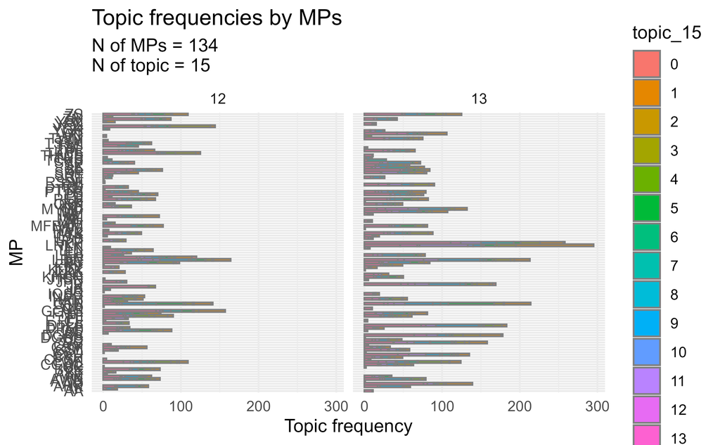

Lets check the correlation between the topics frequencies and ministerial addressees:

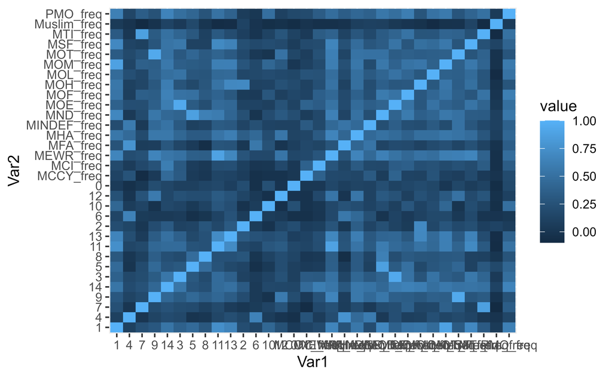

### Extracting principle components:

For dimension reduction, we employ Multiple Factor Analysis (MFA) (Becue-Bertaut and Pages, 2008). MFA is a dimension reduction method that combines traditional principle component analysis and multiple correspondence analysis under one hood. The motivation behind our dimension reduction is two folds. First, our indicators are of different type and different scale. Most geometry based clustering algorithms such as k-means and k-medioids are extremely sensitive to variable type and scale. By applying MFA, we would be rescaling our indicators and convert them into same type (i.e continious). Secondly, we have 44 indicators in total measuring 4 different dimensions;social identity, electoral motivations,political micro-institutions and representative performance. A clustering based on 44 variables would risk unsatisfactory groups due to idiosyncratic variance in variables thus producing hard to understand results. Applying MFA eliminates the risk of idiosyncratic variance in the clustering, thus making clustering results more coherent.

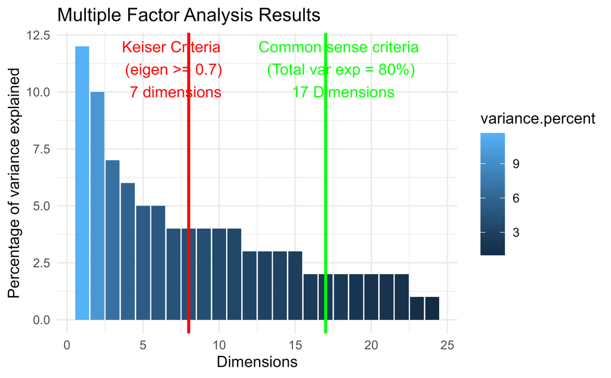

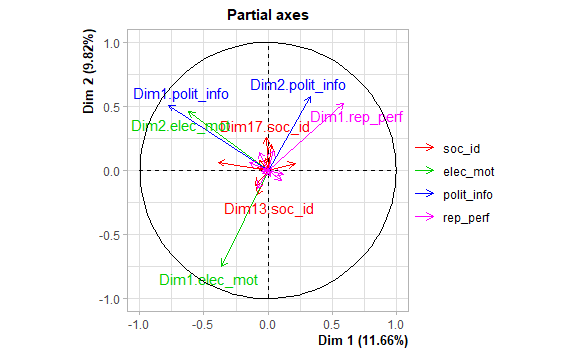

### Clustering:

```
*** : The Hubert index is a graphical method of determining the number of clusters.
                In the plot of Hubert index, we seek a significant knee that corresponds to a
                significant increase of the value of the measure i.e the significant peak in Hubert
                index second differences plot.
```

```
*** : The D index is a graphical method of determining the number of clusters.
                In the plot of D index, we seek a significant knee (the significant peak in Dindex
                second differences plot) that corresponds to a significant increase of the value of
                the measure.

* Among all indices:
* 5 proposed 2 as the best number of clusters
* 2 proposed 3 as the best number of clusters
* 2 proposed 4 as the best number of clusters
* 5 proposed 5 as the best number of clusters
* 1 proposed 6 as the best number of clusters
* 1 proposed 7 as the best number of clusters
* 6 proposed 9 as the best number of clusters
* 1 proposed 10 as the best number of clusters

                   ***** Conclusion *****

* According to the majority rule, the best number of clusters is  9
```

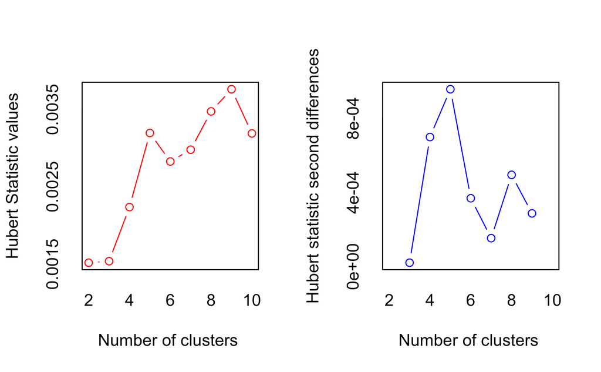

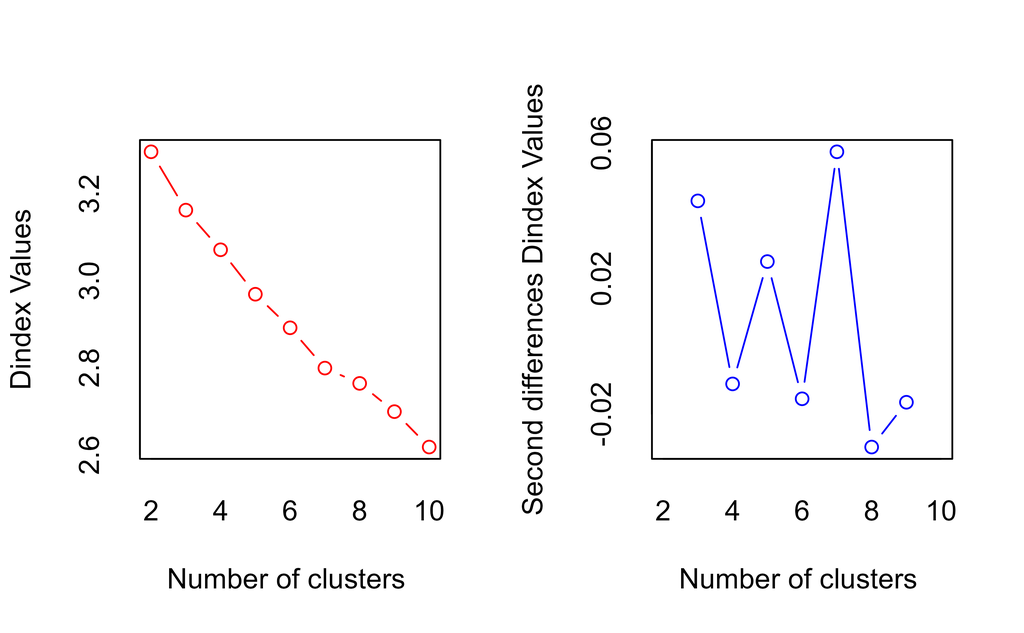

(#tab:cluster_manual_viz)Modes of Social identity indicators for Clusters

| cluster | Race_mode | Gender_mode | Edu_mode | Career_mode | Age_mode |
| --- | --- | --- | --- | --- | --- |
| 1 | Others | Male | Bachelor | Law | 26-40 |
| 2 | Chinese | Male | Master | Biz | 26-40 |
| 3 | Chinese | Male | Master | Technical | 51-62 |
| 4 | Chinese | Male | Bachelor | Fin | 46-51 |
| 5 | Chinese | Female | Bachelor | Culture | 26-40 |
| 6 | Chinese | Male | Master | Biz | 51-62 |
| 7 | Chinese | Male | Bachelor | Biz | 51-62 |
| 8 | Chinese | Female | Master | SS | 40-46 |
| 9 | Chinese | Male | PhD | Acad | 51-62 |

(#tab:cluster_manual_viz)Means of Electoral motivation indicators for Clusters

| cluster | avg_Exp | avg_Win | Ret |
| --- | --- | --- | --- |
| 1 | 2 | 63 | 0.00 |
| 2 | 0 | 66 | 0.04 |
| 3 | 0 | 48 | 0.25 |
| 4 | 1 | 68 | 0.21 |
| 5 | 0 | 63 | 1.00 |
| 6 | 0 | 64 | 1.00 |
| 7 | 2 | 66 | 0.75 |
| 8 | 1 | 62 | 0.50 |
| 9 | 1 | 67 | 0.80 |

(#tab:cluster_manual_viz)Modes of Political micro-institution indicators for Clusters

| cluster | GRC_mode | MP_mode | Party_mode |
| --- | --- | --- | --- |
| 1 | GRC | MP | PAP |
| 2 | GRC | MP | PAP |
| 3 | Not Applicable | NCMP | WP |
| 4 | GRC | MP | PAP |
| 5 | Not Applicable | NMP | NMP |
| 6 | Not Applicable | NMP | NMP |
| 7 | GRC | MP | PAP |
| 8 | GRC | MP | PAP |
| 9 | Not Applicable | NMP | NMP |

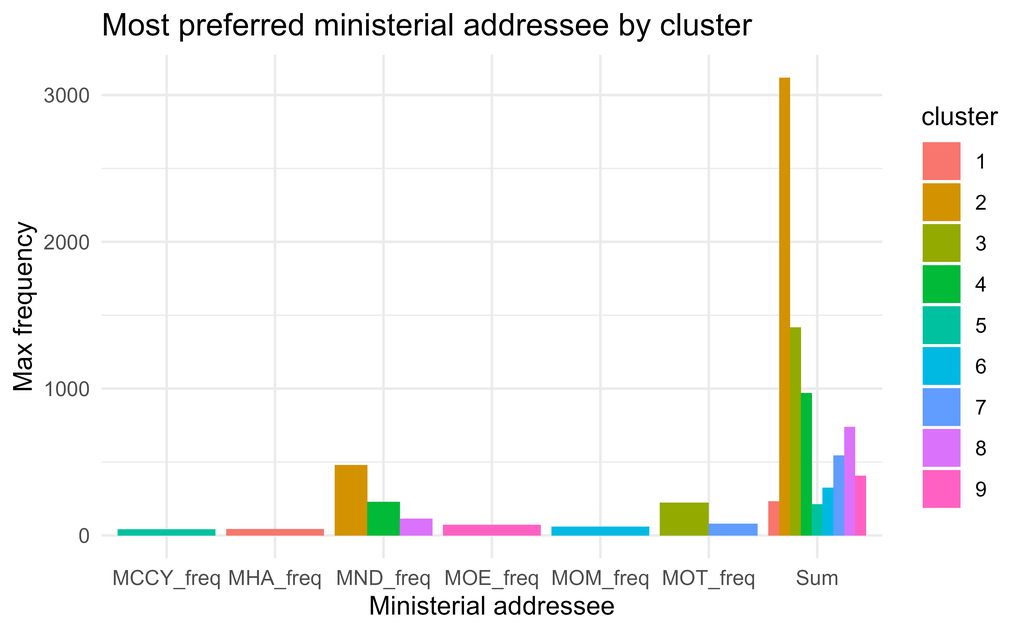